# Using Spatial Analysis to Understand Access to Higher Education

3/30/2018

## Postsecondary Education and Earnings

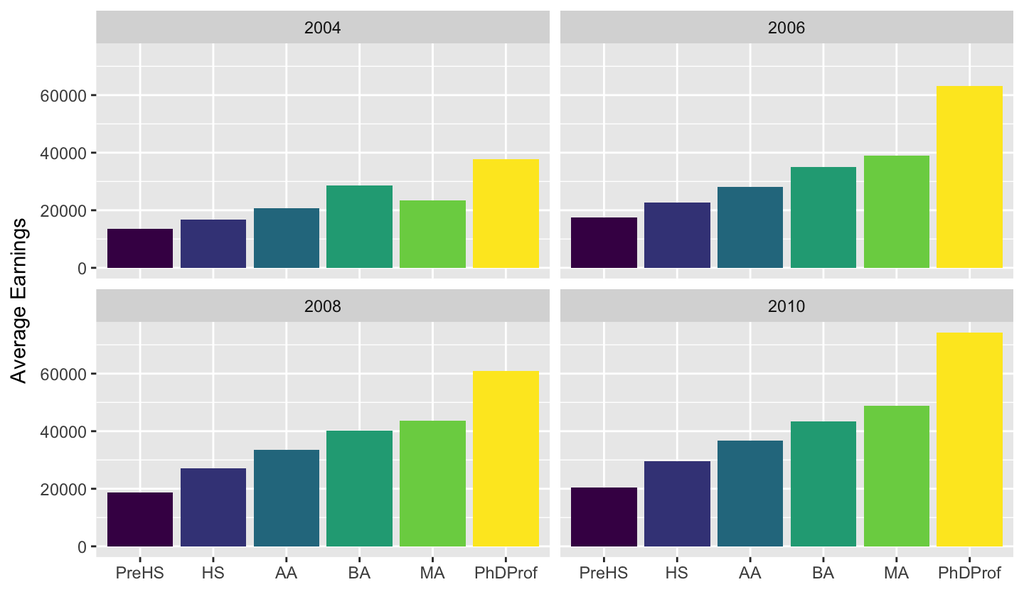

## Postsecondary Education and Voting

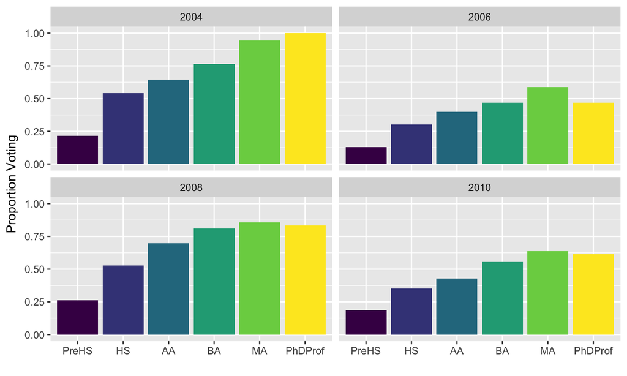

## Data Sources

- United States Census Bureau, Tiger Shapefiles: Geographic boundary information from census block to state level
- Census Bureau, American Community Survey: 2.3 million respondents (Public Use Microdata Sample)
- National Center for Education Statistics,Integrated Postsecondary Education Data System (IPEDS): Data on ~4,500 institutions of higher education in the United States
- Bureau of Labor Statistics, National Longitudinal Survey of Youth, 1997 (NLSY97): Longitudinal data on ~9,000 individuals who were between 14-18 in 1997.
- Educational Longitudinal Survey: Longitudinal data on ~16,000 individuals who were high school sophomores as of 2002.

## Tools

- R as both statistical programming language and GIS
- RStudio as IDE
- Git/Github for version control/collaboration
- Gitter for project related communication
- Leaflet for spatial visualization
- D3 for interactive graphics

## Measuring Geographic Opportunity

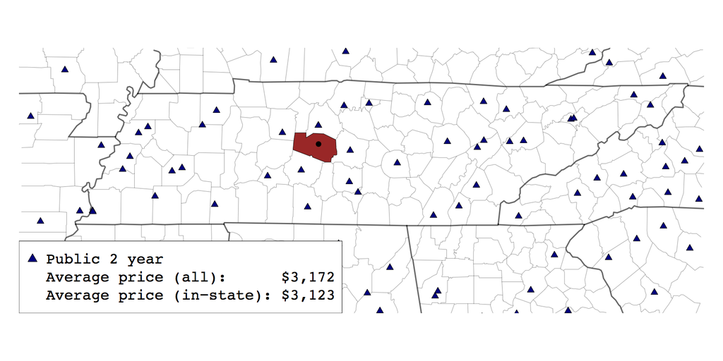

## Inverse Log Distance and Distance Weighting

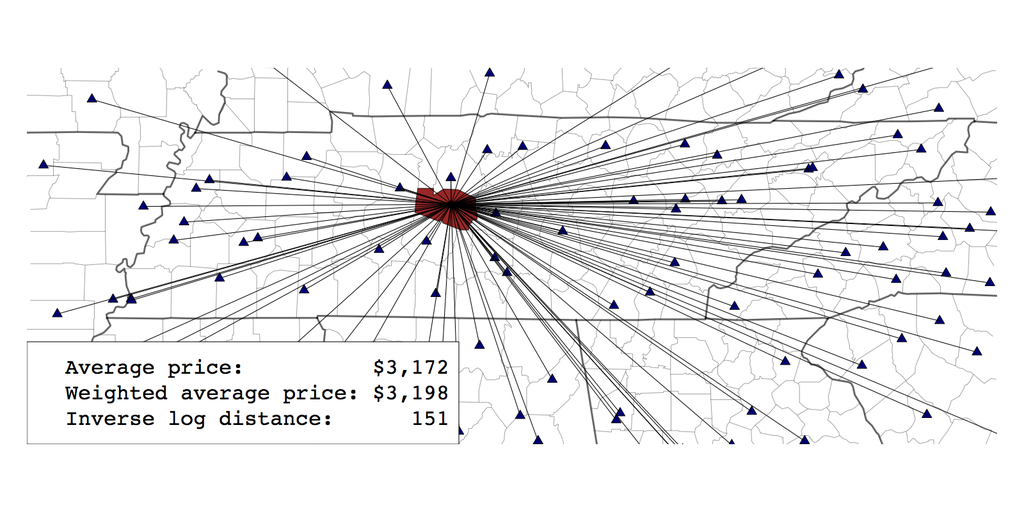

## Inverse Log Distance and Distance Weighting, with Restrictions

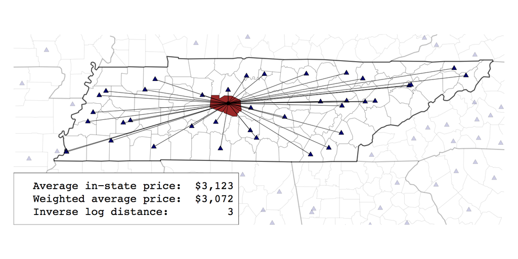

## Variation in Geographic Opportunity

[Measuring College Opportunity](http://btskinner.me/collegeopp)

[College Affordability Diagnosis](http://peabody.vanderbilt.edu/research/studies/affordability/maps_cc.php)

## Variation in Geographic Opportunity by State

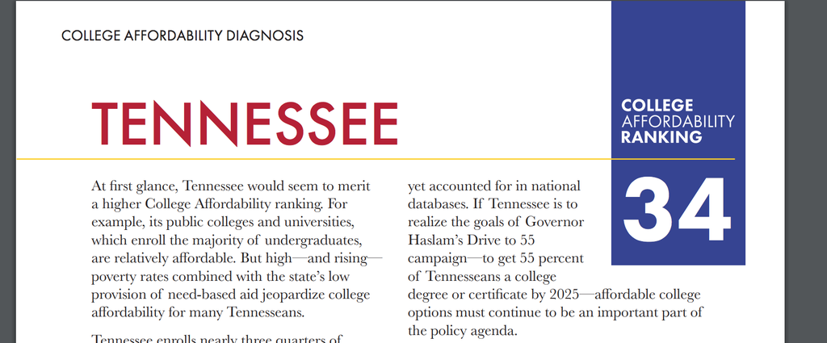

## Variation in Geographic Opportunity by State

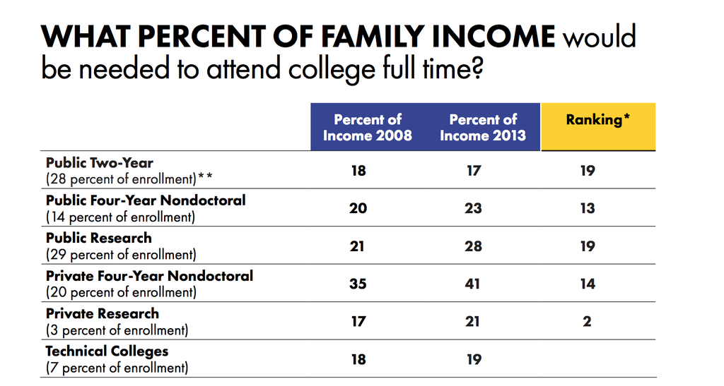

## Variation in Geographic Opportunity by State

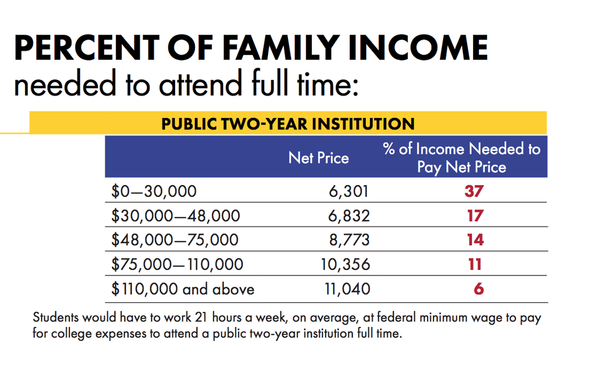

## Summary of Results,Earnings

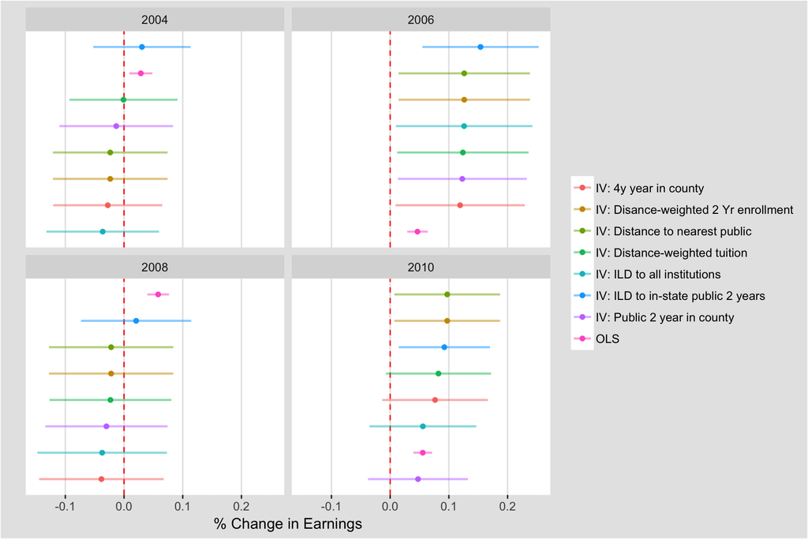

## Summary of Results, Earnings 2010 Only

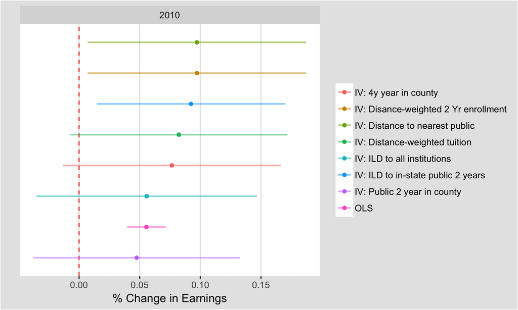

## Summary of Results, Voting 2010 Only

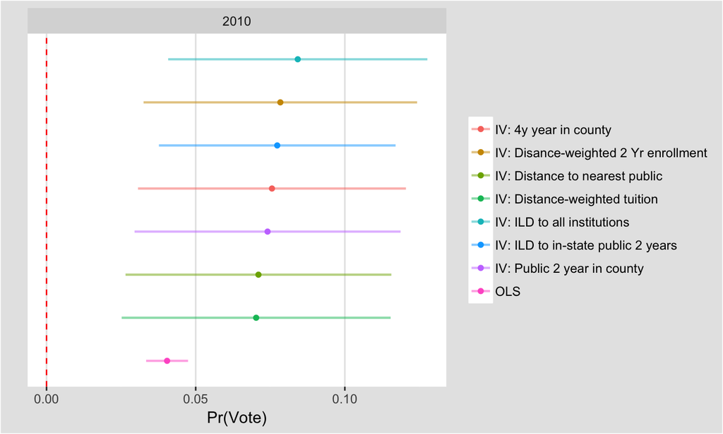

## Further Extensions

- Travel Time, Academic Intensity and Outcomes
- Democratization, Diversion and For-Profits
- Borrowing At Community Colleges

## HOD 3200: Intro to Data Science

- Getting Data
  - Tools of the trade: R/Rstudio/Github
  - Flat files: csv, other formats
  - Webscraping/APIs
  - Simple database queries
- Analyzing Data
  - Conditional means
  - Linear regression
  - Classification– logistic regression
  - Clustering
- Presenting Data
  - Using literate programming (Rmarkdown)
  - Basic plots
  - Interactive graphics
  - Mapping
  - Faceting/ complex graphics

## HOD 3200, Intro to Data Science Example Student Projects

- Predicting performance in PGA tournaments
- Predicting number of undocumented arrivals who are minors
- Predicting airline ticket prices to Shanghai in December
- Predicting performance of different stock portfolios

## Thank You

email: w.doyle@vanderbilt.edu

twitter: @wdoyle42

github: github.com/wdoyle42